# Aides Drug

Dom Ciriello

20210216

# Introduction

A new preventative aides drug (triUmpsal) is under test in clinical trials. Consider only the females, does this drug seem effective? Hint - use dplyr to obtain that subpopulation with the filter command.

# Results

## Descriptive Results

### Graphical Descriptive Results

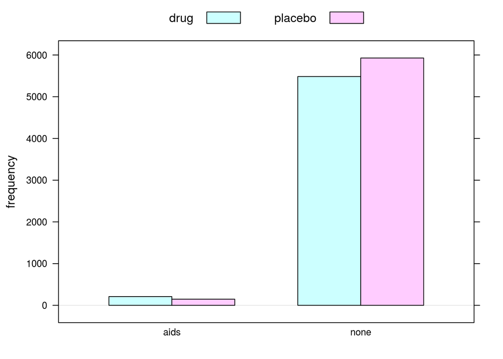

```r
barchartGC(~infected + treatment,data=triuUmpF)
```

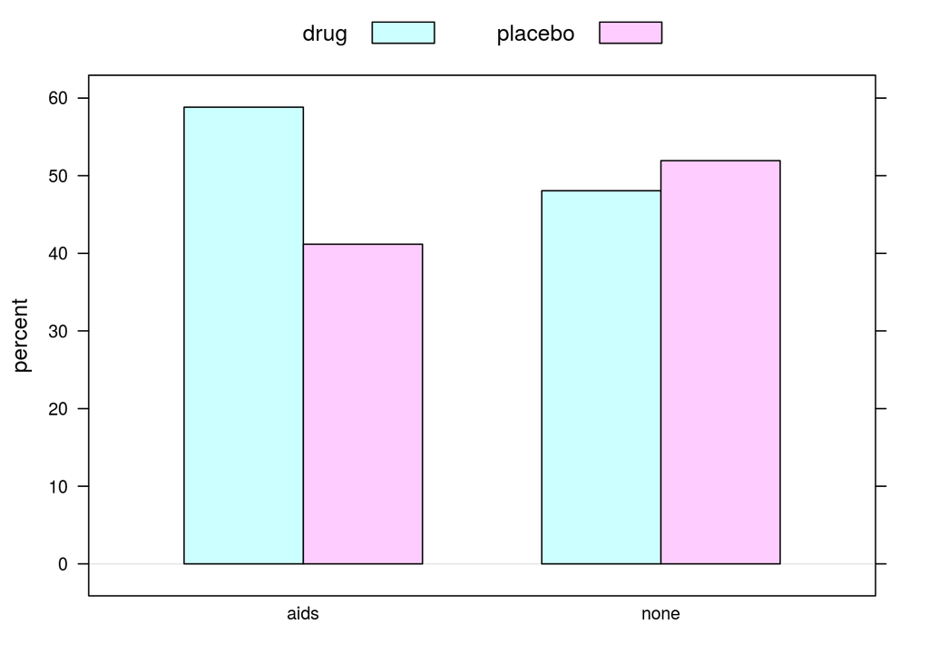

```r
barchartGC(~infected + treatment,data=triuUmpF, type="percent")
```

The plot shows that women who received the vaccine were more likey to contract AIDS.

### Numerical Descriptive Results

```r
table1 <- xtabs(~infected + treatment,data=triuUmpF)
rowPerc(table1)
```

```
##         treatment
## infected   drug placebo  Total
##     aids  58.82   41.18 100.00
##     none  48.06   51.94 100.00
```

```r
colPerc(table1)
```

```
##         treatment
## infected   drug placebo
##    aids    3.69    2.42
##    none   96.31   97.58
##    Total 100.00  100.00
```

The table results show that women are more susceptible to contracting AIDS after taking the drug/vaccine. Out of the women who got aids, 59% of them got the vaccine, and 41% got the placebo.

## Inferential Results

```r
chisq.test(table1)
```

```
##
##  Pearson's Chi-squared test with Yates' continuity correction
##
## data:  table1
## X-squared = 15.634, df = 1, p-value = 7.686e-05
```

```r
chisqtestGC(table1)
```

```
## Pearson's Chi-squared test with Yates' continuity correction
##
## Observed Counts:
##         treatment
## infected drug placebo
##     aids  210     147
##     none 5484    5927
##
## Counts Expected by Null:
##         treatment
## infected    drug placebo
##     aids  172.74  184.26
##     none 5521.26 5889.74
##
## Contributions to the chi-square statistic:
##         treatment
## infected drug placebo
##     aids 8.04    7.54
##     none 0.25    0.24
##
##
## Chi-Square Statistic = 15.6339
## Degrees of Freedom of the table = 1
## P-Value = 1e-04
```

```r
fisher.test(table1)
```

```
##
##  Fisher's Exact Test for Count Data
##
## data:  table1
## p-value = 6.596e-05
## alternative hypothesis: true odds ratio is not equal to 1
## 95 percent confidence interval:
##  1.240408 1.925729
## sample estimates:
## odds ratio
##   1.543902
```

the P-Value is 0.00006596. The number is so small, it is extremely unlikely to have our results to occur by chance.

The odds ratio of 1.543902 means that the women who got the vaccine were approximately 1.5 times more likely to contract AIDS than the women who received the placebo.

# Discussion and Conclusion

The drug is not effective for females. Based on our results, the drug causes females to become more susceptible to contracting AIDS. It failed the clinical test.